# Opportunities for improvement in the care of adult trauma patients arriving in shock

Carl Skog

# Introduction

## Epidemiology

Trauma is a major global public health concern. It causes over four million deaths, among those younger populations are the most affected(1). Globally low and middle income countries are disproportionately affected, while high income countries like Sweden have lower overall numbers but the younger and economically active demographic are also affected. In Sweden between 2018 and 2021, the most common age demographic for trauma is the working aged population, between 18 and 64 years old(2). This not only leads to premature loss of life but also imposes a substantial socio-economic burden, due to long-term disabilities and rehabilitation needs(1).

## Trauma

Trauma is generally divided into two groups, blunt and penetrating injury. The most common type in Sweden is blunt injury, constituting around 90% of all trauma. The most common causes for blunt trauma are traffic related and falls, which account for roughly ½ and ⅓ of all blunt trauma(2).

Penetrating trauma, often caused by gunshots or stab wounds, commonly affects the small intestine, colon, liver, and intra-abdominal blood vessels. These injuries are life-threatening due to significant bleeding from large vessels and the liver’s extensive blood supply. There is also a risk of other complications, such as pancreatic damage leading to autodigestion, and intestinal perforation resulting in contamination from fecal matter. Consequently, penetrating trauma frequently leads to hypovolemic shock and peritonitis(4).

A consequence of both types of trauma is the possibility of significant bleeding, which in turn can result in hemorrhagic shock.

## Shock

The definition for shock is circulatory failure leading to insufficient perfusion and oxygenation of tissue and organ(5). Some of the common symptoms are tachycardia, hypotenstion and altered mental status. Shock are usually classified into four different types based on physiological mechanism. The types are: hypovolemic, obstructive, cardiogenic and distributive, and they all have their own special characteristics(6). These causes can occur alone or in combination, as there can be multiple disruptions on the circulatory system. Examples of diagnoses for each type are, hypovolemic - bleeding, obstructive - tension pneumothorax, cardiogenic - myocardial pump failure and distributive - sepsis(6).

The most common type of shock during trauma is the hypovolemic type due to a major hemorrhage(7). Hemorrhage leads to low blood volume, which beside the common central symptoms noted before, also results in peripheral vasoconstriction, which corresponds with cold, wet and pale extremities(8).

## Shock classifications

To assess the severity of trauma shock, patients can be categorized by stratifying symptoms and physiological parameters into degrees. Although no single international standard exists for such classifications, there is Advanced Trauma Life Support (ATLS) system for major hemorrhage, which is part of the internationally recognised ATLS trauma management course curriculum(9). This system stratifies patients into four shock classes based on estimated blood loss, heart rate (HR), blood pressure (BP), pulse pressure, respiratory rate (RR), mental status, and urine output(9). However, studies have indicated that the ATLS classification has limited prognostic accuracy(10) and is often impractical for clinical use(11), which may explain the low uptake in practice(12).

**ATLS 10th edition**

| **Parameter** | **Class I** | **Class II** (Mild) | **Class III** (Moderate) | **Class IV** (Severe) |
| --- | --- | --- | --- | --- |
| Approximate blood loss | <15% | 15–30% | 31–40% | >40% |
| Heart rate | ↔︎ | ↔︎/↑ | ↑ | ↑/↑↑ |
| Blood pressure | ↔︎ | ↔︎ | ↔︎/↓ | ↓ |
| Pulse pressure | ↔︎ | ↓ | ↓ | ↓ |
| Respiratory rate | ↔︎ | ↔︎ | ↔︎/↑ | ↑ |
| Urine output | ↔︎ | ↔︎ | ↓ | ↓↓ |
| Glasgow Coma Scale score | ↔︎ | ↔︎ | ↓ | ↓ |
| Base deficit | 0 to –2 mEq/L | –2 to –6 mEq/L | –6 to –10 mEq/L | –10 mEq/L or less |
| Need for blood products | Monitor | Possible | Yes | Massive Transfusion Protocol |

Ultimately, the shared foundation of these classifications lies in their reliance on vital signs and additional clinical indicators, underscoring the importance of physiological metrics in assessing shock severity across different clinical settings.

## Trauma quality improvement and oppertunities for improvement

The initial management of trauma patients once they reach hospital is very time sensitive and error prone(7,14,15). To address this and other challenges within trauma care and reduce preventable errors, different types of Quality Improvement (QI) initiatives were initiated. QI focuses on systematically evaluating healthcare processes and patient outcomes, aiming to reduce morbidity and mortality(16). By implementing formal quality measures and conducting collaborative case reviews, QI programs have strengthened trauma systems and improved patient outcomes in various settings globally(17,18).

One way to improve trauma care quality is through identifying Opportunities for Improvement (OFI). This method has an advantage compared to traditional mortality reviews in that it also includes non-fatal outcomes, which gives a broader perspective and a chance to reduce chronic morbidity. There are different processes to finding OFIs, but one of the primary ways is through structured multidisciplinary morbidity and mortality (M&M) reviews of patient cases(16). In order for the review content to be as comprehensive as possible and taking in a system oriented approach, the Donabedian quality of care framework can be used(16,19). It is based on the three factors of structure, process and outcome. By following this framework, healthcare providers will be able to systematically find OFIs as part of QI. This will in turn improve the effectiveness of trauma care, directly impacting mortality and morbidity(17,18).

## Shock and OFI

Shock is the leading cause of preventable death within the first 24 hours of injury(20), with a median time to death from hemorrhagic shock of just 2 hours(21). Despite this, the relationship between shock, its severity, and Opportunities for Improvement (OFI) remains largely unexamined. Most studies on OFI focus on trauma as a whole and do not explore shock in detail, for example, one study (22) noted that 80% of patients had bleeding or hypotension but did not investigate further. However, studying shock more closely is crucial, as it is common, highly preventable, and one of the most deadly. This knowledge would help clinicians better identify and avoid preventable mistakes in shock patients who need urgent care.

## Aims

This study aims to describe the types of opportunities for improvement for adult trauma patients arriving in shock, and to assess how the degree of shock is associated with opportunities for improvement.

# Methods

## Study design

A registry-based retrospective cohort study was conducted using data from the trauma registry and trauma care quality database at the Karolinska University Hospital in Solna.

## Setting

The trauma registry is compromised of patients treated at Karolinska University Hospital in Solna, which treats all major trauma in the greater metropolitan area of Stockholm. We included patients registered between 2014 and 2023. The trauma care quality database is a subset of the trauma registry and includes patients selected for review.

## Participants

Inclusion in the trauma registry requires either admission through trauma team activation or presenting with an Injury Severity Score (ISS) greater than nine after admission to the Karolinska University Hopsital. Each trauma patient is then included in a morbidity and mortality review process, which involves both individual case evaluations by specialized nurses and audit filters. Patients identified with a high potential for OFIs are discussed at multidisciplinary conferences. The identified OFIs are then categorized into broad and detailed categories. The presence or absence of OFIs is determined by consensus among all participants and is documented in the trauma care quality database.

All patients in the trauma registry and Trauma care quality database were included. Patients younger than 15 and/or were dead on arrival were excluded.

## Variables and data sources/measurements

The outcome was defined as the presence of at least one OFI, determined by the multidisciplinary M&M conference in the trauma care quality registry. An OFI can be various types of errors, which are categorized into: clinical judgment error, inadequate resources, delay in treatment, missed injury, inadequate protocols, preventable death and other errors. Patients were classified into different shock severity categories in parallel and separately, once with systolic blood pressure (SBP) and once with base excess (BE), irrespective of shock cause. Based on these two parameters, the patients will be classified into four classes roughly based on the ATLS trauma shock classifications. Five other metrics were included to be adjusted for, due to potential for confounding. Pre-injury ASA and gender were categorical, meanwhile age, ISS and INR were kept continuous as they were directly from the register.

## Study size

All available data in trauma registry and trauma care quality database were included.

## Quantitative variables

The BE parameter was divided into four classes with these cutoffs: Class I (above -2), Class II (-2 to -6), Class III (-6 to -10), and Class IV (below -10). Similarly, SBP was divided into four classes: Class I (above 110 mmHg), Class II (109-100 mmHg), Class III (99-90 mmHg), and Class IV (below 90 mmHg). This classification follows the tenth edition ATLS hemorrhage classification, which does not specify exact values for any parameter other than BE. To solve this, numerical SBP values were assigned to each class based on findings from Eastridge et al. and Oyetunji et al., who redefined hypotension as 110 mmHg respective 90 mmHg dependent on age(23,24). Therefore, 110 mmHg was set as the lower limit for (Class I: no shock) - (ATLS: normal SBP), and below 90 mmHg for (Class IV: clear shock) - (ATLS: clear hypotension), class 2 and 3 divided equally in between. This also aligns with the classification done by Mutschler et al.(11).

**ATLS tenth edition - Systolic blood pressure and Base excess (BD)**

| **Parameter - original ATLS 10th edition** | **Class I** | **Class II** (Mild) | **Class III** (Moderate) | **Class IV** (Severe) |
| --- | --- | --- | --- | --- |
| Base deficit | 0 to –2 mEq/L | –2 to –6 mEq/L | –6 to –10 mEq/L | –10 mEq/L or less |
| Systolic Blood pressure | ↔︎ | ↔︎ | ↔︎/↓ | ↓ |
| **Parameter - numerical approximated SBP** |  |  |  |  |
| Systolic Blood pressure | >110 mmhg | 109-100 mmhg | 99-90 mmhg | <90 mmhg |

Please note that ATLS classification defines class I for the BE parameter as (0 to -2) however, the original source(25) defines class I as base deficit (Inverted BE) ≤ 2, with no lower limit (i.e. an upper limit for BE). The original source classification was chosen for this study.

## Statistical methods

The statistical analysis was performed using R, a programming language and environment for statistical computing. OFI subcategories was presented as percentage distributions and visualized in a bar chart. Unadjusted logistic regression was used to determine the association between the OFI, and degree of shock defined by BE and SBP classifications. Adjusted logistic regression incorporated other patient factors such as age, sex, preinjury ASA, INR, and ISS. It was presented as odds ratios (OR) between the presence of OFI, and shock classes. The OR was determined with 95% confidence intervals, and a significance level of 5% was used. All statistical analysis was first done on synthetic data and then later implemented on the data collected from the trauma registry and the trauma care quality database to ensure objectivity. Missing data was addressed by listwise deletion.

## Ethics

The handling of registry data and the extraction of information from medical records pose a potential risk to patient privacy. To mitigate this, patients were anonymized after data collection, with personal identity numbers replaced by unique study identifiers.

From a self-determination standpoint, the Swedish trauma registry does not require patient consent for data registration. However, it is mandatory for the caregiver to inform patients of their inclusion in the registry. Patients have the right to view, correct, opt out of, and request the deletion of their data, without any impact on the care they receive.

In this study, data will be presented at the group level, ensuring that no individual patient details can be identified. Ethical approvals have been obtained for this study, with the record numbers: 2021-02541, 2021-03531, and 2023-02975-02.

The benefits of this study, in relation to its risks, are substantial due to its potential to improve care for future critically ill patients. This research is a step toward reducing mortality and morbidity in a significant portion of the younger and economically active population worldwide.

# Results

| **Characteristic** | **Overall** N = 2,010<sup>1</sup> | **No** N = 488<sup>1</sup> | **Yes** N = 1,522<sup>1</sup> | **p-value**<sup>2</sup> |
| --- | --- | --- | --- | --- |
| pt_age_yrs | 58 (36, 80) | 57 (35, 79) | 59 (37, 81) | 0.4 |
| pt_Gender |  |  |  | 0.9 |
| Female | 977 (49%) | 238 (49%) | 739 (49%) |  |
| Male | 1,033 (51%) | 250 (51%) | 783 (51%) |  |
| pt_asa_preinjury |  |  |  | 0.2 |
| 1 | 511 (25%) | 116 (24%) | 395 (26%) |  |
| 2 | 498 (25%) | 138 (28%) | 360 (24%) |  |
| 3 | 490 (24%) | 117 (24%) | 373 (25%) |  |
| 4 | 511 (25%) | 117 (24%) | 394 (26%) |  |
| ed_sbp_value | 141 (95, 194) | 139 (93, 191) | 141 (96, 195) | 0.4 |
| ISS | 25 (12, 41) | 26 (12, 42) | 25 (12, 41) | 0.5 |
| ofi.categories.detailed |  |  |  |  |
| Communication | 18 (15%) | 0 (NA%) | 18 (15%) |  |
| Inadequate routine | 2 (1.6%) | 0 (NA%) | 2 (1.6%) |  |
| Level of care | 17 (14%) | 0 (NA%) | 17 (14%) |  |
| Logistics/technical | 18 (15%) | 0 (NA%) | 18 (15%) |  |
| Missed injury | 2 (1.6%) | 0 (NA%) | 2 (1.6%) |  |
| Patient management | 14 (11%) | 0 (NA%) | 14 (11%) |  |
| Patient management/logistics | 17 (14%) | 0 (NA%) | 17 (14%) |  |
| Resources | 16 (13%) | 0 (NA%) | 16 (13%) |  |
| Trauma criteria/guidelines | 1 (0.8%) | 0 (NA%) | 1 (0.8%) |  |
| Triage in the ED | 19 (15%) | 0 (NA%) | 19 (15%) |  |
| Unknown | 1,886 | 488 | 1,398 |  |
| ofi.categories.broad |  |  |  |  |
| Clinical judgement error | 68 (55%) | 0 (NA%) | 68 (55%) |  |
| Inadequate protocols | 3 (2.4%) | 0 (NA%) | 3 (2.4%) |  |
| Inadequate resources | 34 (27%) | 0 (NA%) | 34 (27%) |  |
| Missed diagnosis | 2 (1.6%) | 0 (NA%) | 2 (1.6%) |  |
| Other errors | 17 (14%) | 0 (NA%) | 17 (14%) |  |
| Unknown | 1,886 | 488 | 1,398 |  |
| ed_be_art_numeric | -6 (-14, 2) | -7 (-16, 0) | -6 (-14, 3) | <0.001 |
| ed_inr_numeric | 3.00 (1.70, 4.20) | 3.10 (1.80, 4.60) | 2.90 (1.70, 4.20) | 0.037 |
| BE_class |  |  |  | 0.010 |
| Class 1 | 762 (38%) | 155 (32%) | 607 (40%) |  |
| Class 2 | 251 (12%) | 72 (15%) | 179 (12%) |  |
| Class 3 | 261 (13%) | 65 (13%) | 196 (13%) |  |
| Class 4 | 736 (37%) | 196 (40%) | 540 (35%) |  |
| V4SBP_class |  |  |  | 0.9 |
| Class 1 | 1,337 (67%) | 318 (65%) | 1,019 (67%) |  |
| Class 2 | 114 (5.7%) | 28 (5.7%) | 86 (5.7%) |  |
| Class 3 | 117 (5.8%) | 31 (6.4%) | 86 (5.7%) |  |
| Class 4 | 442 (22%) | 111 (23%) | 331 (22%) |  |

<sup>1</sup> Median (Q1, Q3); n (%)  
<sup>2</sup> Wilcoxon rank sum test; Pearson’s Chi-squared test

[output not shown]

<sup>1</sup> OR = Odds Ratio, CI = Confidence Interval

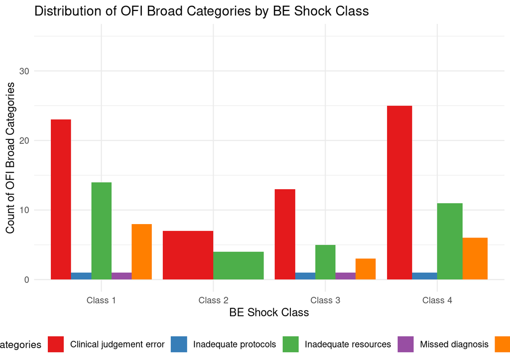

| **Characteristic** | **Class 1** N = 762<sup>1</sup> | **Class 2** N = 251<sup>1</sup> | **Class 3** N = 261<sup>1</sup> | **Class 4** N = 736<sup>1</sup> |
| --- | --- | --- | --- | --- |
| ofi.categories.broad |  |  |  |  |
| Clinical judgement error | 23 (49%) | 7 (64%) | 13 (57%) | 25 (58%) |
| Inadequate protocols | 1 (2.1%) | 0 (0%) | 1 (4.3%) | 1 (2.3%) |
| Inadequate resources | 14 (30%) | 4 (36%) | 5 (22%) | 11 (26%) |
| Missed diagnosis | 1 (2.1%) | 0 (0%) | 1 (4.3%) | 0 (0%) |
| Other errors | 8 (17%) | 0 (0%) | 3 (13%) | 6 (14%) |
| Unknown | 715 | 240 | 238 | 693 |

<sup>1</sup> n (%)

| **Characteristic** | **Adjusted Model** **Event Rate** | **Adjusted Model** **OR**<sup>1</sup> | **Adjusted Model** **95% CI**<sup>1</sup> | **Adjusted Model** **p-value** | **Unadjusted Model** **OR**<sup>1</sup> | **Unadjusted Model** **95% CI**<sup>1</sup> | **Unadjusted Model** **p-value** |
| --- | --- | --- | --- | --- | --- | --- | --- |
| Shock classification - BE |  |  |  |  |  |  |  |
| Class 1 | 607 / 762 (80%) | — | — |  | — | — |  |
| Class 2 | 179 / 251 (71%) | 0.64 | 0.46, 0.89 | 0.008 | 0.63 | 0.46, 0.88 | 0.006 |
| Class 3 | 196 / 261 (75%) | 0.76 | 0.55, 1.06 | 0.10 | 0.77 | 0.55, 1.08 | 0.12 |
| Class 4 | 540 / 736 (73%) | 0.70 | 0.55, 0.89 | 0.004 | 0.70 | 0.55, 0.89 | 0.004 |
| Age (Years) | 1,522 / 2,010 (76%) | 1.00 | 1.00, 1.01 | 0.4 |  |  |  |
| Gender (M/F) |  |  |  |  |  |  |  |
| Female | 739 / 977 (76%) | — | — |  |  |  |  |
| Male | 783 / 1,033 (76%) | 1.00 | 0.81, 1.23 | 0.9 |  |  |  |
| Pre-injury ASA |  |  |  |  |  |  |  |
| 1 | 395 / 511 (77%) | — | — |  |  |  |  |
| 2 | 360 / 498 (72%) | 0.78 | 0.58, 1.04 | 0.089 |  |  |  |
| 3 | 373 / 490 (76%) | 0.95 | 0.71, 1.28 | 0.7 |  |  |  |
| 4 | 394 / 511 (77%) | 1.00 | 0.74, 1.34 | 0.9 |  |  |  |
| INR | 1,522 / 2,010 (76%) | 0.95 | 0.91, 1.00 | 0.034 |  |  |  |
| Injury Severity Score | 1,522 / 2,010 (76%) | 1.00 | 0.99, 1.00 | 0.3 |  |  |  |

<sup>1</sup> OR = Odds Ratio, CI = Confidence Interval

## Participants

There were a total of 11864 patients in the trauma registry. After excluding the patients younger than 15 and/or were dead on arrival, there were 5732 patients left. Out of those, 3196 patients had been reviewed for the presence of OFI. A total of 1186 patients were excluded due to missing data, resulting in 2010 patients for the final analysis.

| **Characteristic** | **Overall** N = 3,196<sup>1</sup> | **No** N = 778<sup>1</sup> | **Yes** N = 2,418<sup>1</sup> | **p-value**<sup>2</sup> |
| --- | --- | --- | --- | --- |
| Age (Years) | 58 (36, 79) | 58 (35, 78) | 58 (36, 80) | 0.6 |
| Gender (M/F) |  |  |  | 0.4 |
| Female | 1,573 (49%) | 373 (48%) | 1,200 (50%) |  |
| Male | 1,623 (51%) | 405 (52%) | 1,218 (50%) |  |
| Pre-injury ASA |  |  |  | 0.4 |
| 1 | 540 (26%) | 126 (24%) | 414 (26%) |  |
| 2 | 525 (25%) | 144 (28%) | 381 (24%) |  |
| 3 | 510 (24%) | 123 (24%) | 387 (24%) |  |
| 4 | 540 (26%) | 126 (24%) | 414 (26%) |  |
| Unknown | 1,081 | 259 | 822 |  |
| Systolic blood pressure (mmhg) | 144 (96, 195) | 147 (96, 195) | 143 (96, 195) | 0.8 |
| Unknown | 10 | 3 | 7 |  |
| Injury Severity Score | 25 (12, 41) | 26 (13, 42) | 25 (12, 41) | 0.5 |
| Unknown | 65 | 16 | 49 |  |
| OFI categories detailed |  |  |  |  |
| Communication | 29 (14%) | 0 (NA%) | 29 (14%) |  |
| Competence | 1 (0.5%) | 0 (NA%) | 1 (0.5%) |  |
| Inadequate routine | 2 (1.0%) | 0 (NA%) | 2 (1.0%) |  |
| Level of care | 30 (15%) | 0 (NA%) | 30 (15%) |  |
| Logistics/technical | 30 (15%) | 0 (NA%) | 30 (15%) |  |
| Missed injury | 2 (1.0%) | 0 (NA%) | 2 (1.0%) |  |
| Patient management | 30 (15%) | 0 (NA%) | 30 (15%) |  |
| Patient management/logistics | 26 (13%) | 0 (NA%) | 26 (13%) |  |
| Resources | 28 (14%) | 0 (NA%) | 28 (14%) |  |
| Tertiary survey | 1 (0.5%) | 0 (NA%) | 1 (0.5%) |  |
| Trauma criteria/guidelines | 1 (0.5%) | 0 (NA%) | 1 (0.5%) |  |
| Triage in the ED | 26 (13%) | 0 (NA%) | 26 (13%) |  |
| Unknown | 2,990 | 778 | 2,212 |  |
| OFI categories broad |  |  |  |  |
| Clinical judgement error | 115 (56%) | 0 (NA%) | 115 (56%) |  |
| Inadequate protocols | 3 (1.5%) | 0 (NA%) | 3 (1.5%) |  |
| Inadequate resources | 59 (29%) | 0 (NA%) | 59 (29%) |  |
| Missed diagnosis | 3 (1.5%) | 0 (NA%) | 3 (1.5%) |  |
| Other errors | 26 (13%) | 0 (NA%) | 26 (13%) |  |
| Unknown | 2,990 | 778 | 2,212 |  |
| Base Excess (BE) | -6 (-14, 2) | -6 (-15, 1) | -6 (-14, 2) | 0.030 |
| Unknown | 14 | 5 | 9 |  |
| INR | 3.00 (1.70, 4.40) | 3.10 (1.80, 4.40) | 2.90 (1.70, 4.20) | 0.2 |
| Unknown | 62 | 16 | 46 |  |
| Shock classification - BE |  |  |  | 0.066 |
| Class 1 | 1,212 (38%) | 266 (34%) | 946 (39%) |  |
| Class 2 | 409 (13%) | 114 (15%) | 295 (12%) |  |
| Class 3 | 399 (13%) | 99 (13%) | 300 (12%) |  |
| Class 4 | 1,162 (37%) | 294 (38%) | 868 (36%) |  |
| Unknown | 14 | 5 | 9 |  |
| Shock classification - SBP |  |  |  | 0.6 |
| Class 1 | 2,161 (68%) | 530 (68%) | 1,631 (68%) |  |
| Class 2 | 168 (5.3%) | 34 (4.4%) | 134 (5.6%) |  |
| Class 3 | 173 (5.4%) | 40 (5.2%) | 133 (5.5%) |  |
| Class 4 | 684 (21%) | 171 (22%) | 513 (21%) |  |
| Unknown | 10 | 3 | 7 |  |

<sup>1</sup> Median (Q1, Q3); n (%)  
<sup>2</sup> Wilcoxon rank sum test; Pearson’s Chi-squared test

## Descriptive data

[output not shown]

<sup>1</sup> Median (Q1, Q3); n (%)  
<sup>2</sup> Wilcoxon rank sum test; Pearson’s Chi-squared test

## Outcome data

Out of the 3196 patients reviewed, 2418 (75.7%) patients had at least one positive OFI.

Counts and Percentages of OFI Broad Categories by BE Shock Class

| BE Shock Class | OFI Category | Count | Percentage (%) |
| --- | --- | --- | --- |
| **Class 1** |  |  |  |
| Class 1 | Clinical judgement error | 23 | 48.9 |
| Class 1 | Inadequate protocols | 1 | 2.1 |
| Class 1 | Inadequate resources | 14 | 29.8 |
| Class 1 | Missed diagnosis | 1 | 2.1 |
| Class 1 | Other errors | 8 | 17.0 |
| **Class 2** |  |  |  |
| Class 2 | Clinical judgement error | 7 | 63.6 |
| Class 2 | Inadequate resources | 4 | 36.4 |
| **Class 3** |  |  |  |
| Class 3 | Clinical judgement error | 13 | 56.5 |
| Class 3 | Inadequate protocols | 1 | 4.3 |
| Class 3 | Inadequate resources | 5 | 21.7 |
| Class 3 | Missed diagnosis | 1 | 4.3 |
| Class 3 | Other errors | 3 | 13.0 |
| **Class 4** |  |  |  |
| Class 4 | Clinical judgement error | 25 | 58.1 |
| Class 4 | Inadequate protocols | 1 | 2.3 |
| Class 4 | Inadequate resources | 11 | 25.6 |
| Class 4 | Other errors | 6 | 14.0 |

Counts and Percentages of OFI Broad Categories by BE and SBP Shock Classes

[output not shown]

[figure not shown]